# Lab_5_Submission_Group_1

## LAB 5 - Group 1

#### Nikita Chinchwade

#### Purvi Kakkasagar

#### Shashank Puthanveedu

#### Vatsal Sanghavi

### Pre-processing the data

```python
# Importing the necessary libraries
import pandas as pd
import statsmodels.api as sm
import numpy as np
import matplotlib.pyplot as plt
import seaborn as sns

# Setting the max rows displayed to 500 for better readability
pd.set_option('display.max_columns', 500)
```

```python
# Importing the Scikit packages
from sklearn.model_selection import train_test_split, KFold, GridSearchCV
from sklearn.preprocessing import StandardScaler
from sklearn.linear_model import LinearRegression
from sklearn.tree import DecisionTreeRegressor, export_graphviz
from sklearn.cluster import KMeans
from sklearn.decomposition import PCA
```

```python
# Read the data file
diamonds_df = pd.read_csv('diamonds.csv', parse_dates=True)
```

```python
# Descriptive stats of the data
# Note - only numerical variables are described.
diamonds_df.describe()
```

|  | ID | Carat Weight | Price |
| --- | --- | --- | --- |
| count | 6000.000000 | 6000.000000 | 6000.000000 |
| mean | 3000.500000 | 1.334520 | 11791.579333 |
| std | 1732.195139 | 0.475696 | 10184.350051 |
| min | 1.000000 | 0.750000 | 2184.000000 |
| 25% | 1500.750000 | 1.000000 | 5150.500000 |
| 50% | 3000.500000 | 1.130000 | 7857.000000 |
| 75% | 4500.250000 | 1.590000 | 15036.500000 |
| max | 6000.000000 | 2.910000 | 101561.000000 |

```python
# All possible values for Categorical Variables
diamonds_df['Cut'].value_counts()
```

```
Ideal              2482
Very Good          2428
Good                708
Signature-Ideal     253
Fair                129
Name: Cut, dtype: int64
```

```python
diamonds_df['Color'].value_counts()
```

```
G    1501
H    1079
F    1013
I     968
E     778
D     661
Name: Color, dtype: int64
```

```python
diamonds_df['Clarity'].value_counts()
```

```
SI1     2059
VS2     1575
VS1     1192
VVS2     666
VVS1     285
IF       219
FL         4
Name: Clarity, dtype: int64
```

```python
diamonds_df['Polish'].value_counts()
```

```
EX    2425
VG    2409
ID     595
G      571
Name: Polish, dtype: int64
```

```python
diamonds_df['Symmetry'].value_counts()
```

```
VG    2417
EX    2059
G      916
ID     608
Name: Symmetry, dtype: int64
```

### Exercise 1

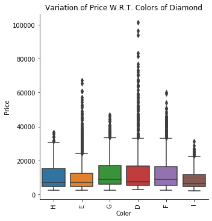

```python
# Plotting the box plot to show the variation of Price with respect to the Color of Diamond
sns.catplot(x="Color", y="Price", hue="Color",
            kind="box", dodge=False, data=diamonds_df);

plt.title('Variation of Price W.R.T. Colors of Diamond')
plt.xticks(rotation='vertical');
```

### Exercise 2

##### Step 2.1

The continuous variable is **Carat Weight** while the rest of the variables viz. **Cut, Color, Clarity, Polish and Symmetry** are categorical variables

```python
# Modifying the data type from int to float
diamonds_df['Price'] = diamonds_df['Price'].astype('float64')
```

```python
# Creating the dummy values for the categorical variables
X = pd.get_dummies(diamonds_df['Cut'], prefix='Cut', prefix_sep='=', drop_first=True)
B = pd.get_dummies(diamonds_df['Color'], prefix='Color', prefix_sep='=', drop_first=True)
C = pd.get_dummies(diamonds_df['Clarity'], prefix='Clarity', prefix_sep='=', drop_first=True)
D = pd.get_dummies(diamonds_df['Polish'], prefix='Polish', prefix_sep='=', drop_first=True)
E = pd.get_dummies(diamonds_df['Symmetry'], prefix='Symmetry', prefix_sep='=', drop_first=True)

# Extracting the only numerical variable in the data 'Carat Weight'
F = diamonds_df['Carat Weight']
X = sm.add_constant(X)
```

```python
# Creating the data frame for regression
regression_df = pd.concat([X, B, C, D, E, F], axis=1)
```

```python
# Dividing the value of Price by 100 to scale down the values.
y = diamonds_df['Price'].div(100)
```

Since the prices have high values, we may see the results of the finding in large numbers represented as exponential numbers. Thus, to make the numbers easier to read, analyze and vizualize we reduce the Price by a fraction of 100. Though the overall results would be the same we divide by 100 which makes it more readable.

Also, we need to multiply the regression coefficients by 100 to get the actual value of the coefficients as we have scaled the actual value down by 100.

```python
# Display the final data set being used for analysis
pd.concat([Test_df, y], axis=1).head()
```

|  | const | Cut=Good | Cut=Ideal | Cut=Signature-Ideal | Cut=Very Good | Color=E | Color=F | Color=G | Color=H | Color=I | Clarity=IF | Clarity=SI1 | Clarity=VS1 | Clarity=VS2 | Clarity=VVS1 | Clarity=VVS2 | Polish=G | Polish=ID | Polish=VG | Symmetry=G | Symmetry=ID | Symmetry=VG | Carat Weight | Price |
| --- | --- | --- | --- | --- | --- | --- | --- | --- | --- | --- | --- | --- | --- | --- | --- | --- | --- | --- | --- | --- | --- | --- | --- | --- |
| 0 | 1.0 | 0 | 1 | 0 | 0 | 0 | 0 | 0 | 1 | 0 | 0 | 1 | 0 | 0 | 0 | 0 | 0 | 0 | 1 | 0 | 0 | 0 | 1.10 | 51.69 |
| 1 | 1.0 | 0 | 1 | 0 | 0 | 0 | 0 | 0 | 1 | 0 | 0 | 0 | 1 | 0 | 0 | 0 | 0 | 1 | 0 | 0 | 1 | 0 | 0.83 | 34.70 |
| 2 | 1.0 | 0 | 1 | 0 | 0 | 0 | 0 | 0 | 1 | 0 | 0 | 1 | 0 | 0 | 0 | 0 | 0 | 0 | 0 | 0 | 0 | 0 | 0.85 | 31.83 |
| 3 | 1.0 | 0 | 1 | 0 | 0 | 1 | 0 | 0 | 0 | 0 | 0 | 1 | 0 | 0 | 0 | 0 | 0 | 0 | 1 | 0 | 0 | 1 | 0.91 | 43.70 |
| 4 | 1.0 | 0 | 1 | 0 | 0 | 0 | 0 | 1 | 0 | 0 | 0 | 1 | 0 | 0 | 0 | 0 | 0 | 0 | 0 | 0 | 0 | 0 | 0.83 | 31.71 |

#### Step 2.2

```python
# Performing OLS Regression
model = sm.OLS(endog=y, exog=regression_df)
results = model.fit()
results.summary()
```

OLS Regression Results

| Dep. Variable: | Price | R-squared: | 0.864 |
| --- | --- | --- | --- |
| Model: | OLS | Adj. R-squared: | 0.863 |
| Method: | Least Squares | F-statistic: | 1720. |
| Date: | Thu, 14 Nov 2019 | Prob (F-statistic): | 0.00 |
| Time: | 18:00:41 | Log-Likelihood: | -30278. |
| No. Observations: | 6000 | AIC: | 6.060e+04 |
| Df Residuals: | 5977 | BIC: | 6.076e+04 |
| Df Model: | 22 |  |  |
| Covariance Type: | nonrobust |  |  |

|  | coef | std err | t | P>\|t\| | [0.025 | 0.975] |
| --- | --- | --- | --- | --- | --- | --- |
| const | 265.8771 | 19.301 | 13.775 | 0.000 | 228.040 | 303.715 |
| Cut=Good | -3.1271 | 3.620 | -0.864 | 0.388 | -10.224 | 3.970 |
| Cut=Ideal | 2.9421 | 3.535 | 0.832 | 0.405 | -3.987 | 9.871 |
| Cut=Signature-Ideal | 16.9901 | 4.378 | 3.881 | 0.000 | 8.408 | 25.572 |
| Cut=Very Good | -0.2262 | 3.446 | -0.066 | 0.948 | -6.982 | 6.530 |
| Color=E | -23.2755 | 2.005 | -11.611 | 0.000 | -27.205 | -19.346 |
| Color=F | -30.8151 | 1.897 | -16.244 | 0.000 | -34.534 | -27.096 |
| Color=G | -48.0178 | 1.782 | -26.946 | 0.000 | -51.511 | -44.524 |
| Color=H | -63.6407 | 1.880 | -33.854 | 0.000 | -67.326 | -59.955 |
| Color=I | -80.4556 | 1.925 | -41.791 | 0.000 | -84.230 | -76.682 |
| Clarity=IF | -270.9266 | 19.120 | -14.170 | 0.000 | -308.408 | -233.445 |
| Clarity=SI1 | -368.9841 | 18.983 | -19.437 | 0.000 | -406.198 | -331.770 |
| Clarity=VS1 | -339.7273 | 18.991 | -17.889 | 0.000 | -376.956 | -302.498 |
| Clarity=VS2 | -353.1302 | 18.988 | -18.598 | 0.000 | -390.353 | -315.907 |
| Clarity=VVS1 | -305.7409 | 19.091 | -16.015 | 0.000 | -343.167 | -268.315 |
| Clarity=VVS2 | -324.3345 | 19.018 | -17.054 | 0.000 | -361.617 | -287.052 |
| Polish=G | 0.0470 | 2.017 | 0.023 | 0.981 | -3.906 | 4.000 |
| Polish=ID | -6.3482 | 7.389 | -0.859 | 0.390 | -20.834 | 8.137 |
| Polish=VG | -1.5314 | 1.264 | -1.211 | 0.226 | -4.010 | 0.947 |
| Symmetry=G | -4.2738 | 1.888 | -2.263 | 0.024 | -7.975 | -0.572 |
| Symmetry=ID | 0.1635 | 7.313 | 0.022 | 0.982 | -14.173 | 14.500 |
| Symmetry=VG | -2.8728 | 1.333 | -2.155 | 0.031 | -5.487 | -0.259 |
| Carat Weight | 183.9475 | 1.051 | 175.015 | 0.000 | 181.887 | 186.008 |

| Omnibus: | 4388.955 | Durbin-Watson: | 2.041 |
| --- | --- | --- | --- |
| Prob(Omnibus): | 0.000 | Jarque-Bera (JB): | 149835.929 |
| Skew: | 3.118 | Prob(JB): | 0.00 |
| Kurtosis: | 26.674 | Cond. No. | 208. |

Warnings:  
[1] Standard Errors assume that the covariance matrix of the errors is correctly specified.

On average, a 1 unit increase in Carat Weight is associated with a **$18394.75** increase in Price.

For the category color, we leave out the value 'D' for our model.

Compared to the price of color 'D', the diamonds having color 'E' will cost **$2327.55** less on average.

#### Step 2.3

```python
# Drop constant column from statsmodels data frame
Test_df.drop('const', axis=1, inplace=True)
Test_df.head()
```

|  | Cut=Good | Cut=Ideal | Cut=Signature-Ideal | Cut=Very Good | Color=E | Color=F | Color=G | Color=H | Color=I | Clarity=IF | Clarity=SI1 | Clarity=VS1 | Clarity=VS2 | Clarity=VVS1 | Clarity=VVS2 | Polish=G | Polish=ID | Polish=VG | Symmetry=G | Symmetry=ID | Symmetry=VG | Carat Weight |
| --- | --- | --- | --- | --- | --- | --- | --- | --- | --- | --- | --- | --- | --- | --- | --- | --- | --- | --- | --- | --- | --- | --- |
| 0 | 0 | 1 | 0 | 0 | 0 | 0 | 0 | 1 | 0 | 0 | 1 | 0 | 0 | 0 | 0 | 0 | 0 | 1 | 0 | 0 | 0 | 1.10 |
| 1 | 0 | 1 | 0 | 0 | 0 | 0 | 0 | 1 | 0 | 0 | 0 | 1 | 0 | 0 | 0 | 0 | 1 | 0 | 0 | 1 | 0 | 0.83 |
| 2 | 0 | 1 | 0 | 0 | 0 | 0 | 0 | 1 | 0 | 0 | 1 | 0 | 0 | 0 | 0 | 0 | 0 | 0 | 0 | 0 | 0 | 0.85 |
| 3 | 0 | 1 | 0 | 0 | 1 | 0 | 0 | 0 | 0 | 0 | 1 | 0 | 0 | 0 | 0 | 0 | 0 | 1 | 0 | 0 | 1 | 0.91 |
| 4 | 0 | 1 | 0 | 0 | 0 | 0 | 1 | 0 | 0 | 0 | 1 | 0 | 0 | 0 | 0 | 0 | 0 | 0 | 0 | 0 | 0 | 0.83 |

```python
X_train, X_test, y_train, y_test = train_test_split(Test_df, y, test_size=0.3, random_state=12345)
```

```python
# Train linear regression model on training set
lr = LinearRegression(fit_intercept=True)
lr.fit(X_train, y_train)
print('The out-of-sample R2 is', lr.score(X_test, y_test))
```

```
The out-of-sample R2 is 0.8612000613453943
```

[figure not shown]

```python
# Predict interest rate for test set, compare to actual interest rates
y_pred = lr.predict(X_test)
plt.figure(figsize=(8,8))
plt.plot(y_pred, y_test, 'k.', alpha=0.25) # don't forget to transform our predictions!
plt.xlim([0,300])
plt.ylim([0,300])
plt.xlabel('Predicted Price')
plt.ylabel('Observed Price')
plt.title('Correlation Coeff: %.4f' % np.corrcoef(y_pred, y_test)[0,1]);
```

The correlation coefficient is **0.9283**. This indicates that the predicted values and the observed values of price are **highly positively correlated**